# Stats 20, F23 – Homework 7

Michelle Navarrete Vega – 805676988

12/06/23

## Question 1

### Part a

```r
births <- read.csv("births.csv", stringsAsFactors = TRUE)
is.factor(births$Habit)
```

```
## [1] TRUE
```

### Part b

```r
table(births$Habit)
```

```
##
##           NonSmoker    Smoker
##         6      1805       187
```

```r
names(table(births$Habit)[1])
```

```
## [1] ""
```

```r
levels(births$Habit)
```

```
## [1] ""          "NonSmoker" "Smoker"
```

There are 6 observations in the category where there is no information regarding the smoking habits of the mother. The name of this category is “” blank.

### Part c

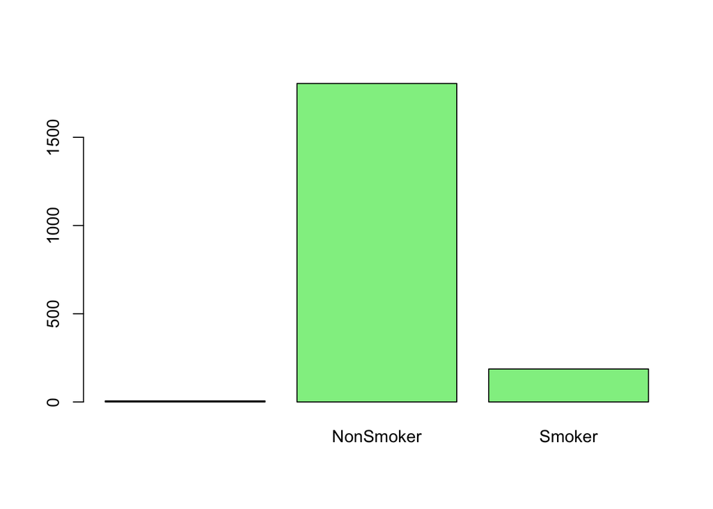

```r
plot(births$Habit, col = "lightgreen")
```

### Part d

```r
known_habit_data <- births[births$Habit %in% c("NonSmoker", "Smoker"), ]

known_habit_data$Habit <- droplevels(known_habit_data$Habit)

levels(known_habit_data$Habit)
```

```
## [1] "NonSmoker" "Smoker"
```

### Part e

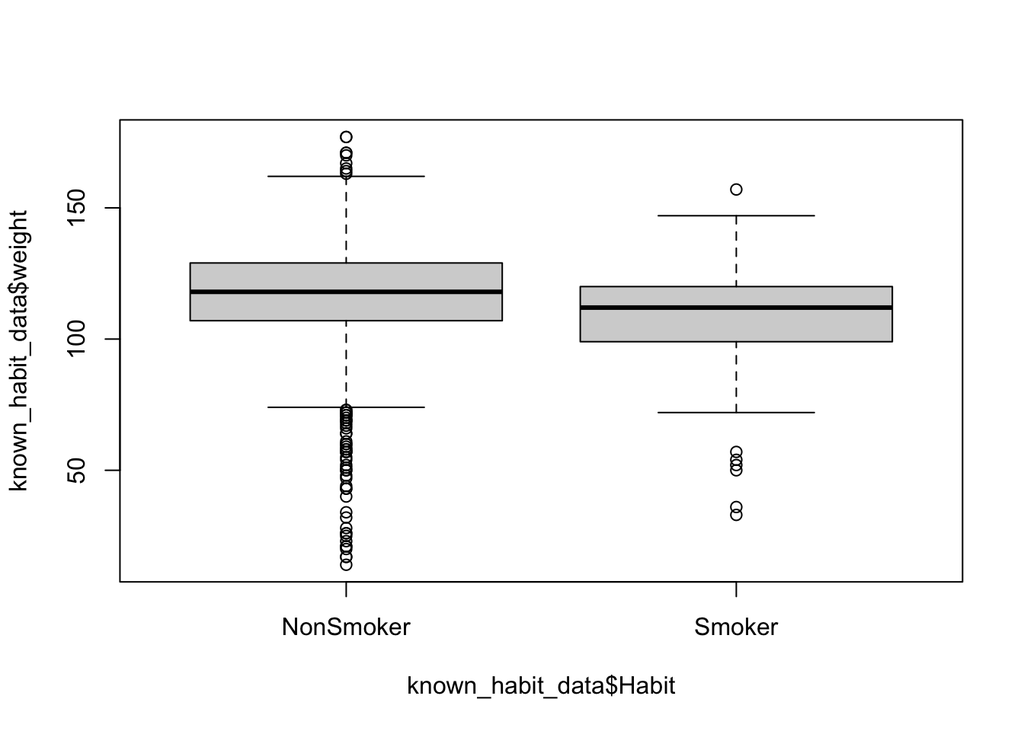

```r
boxplot(known_habit_data$weight~known_habit_data$Habit)
```

## Question 2

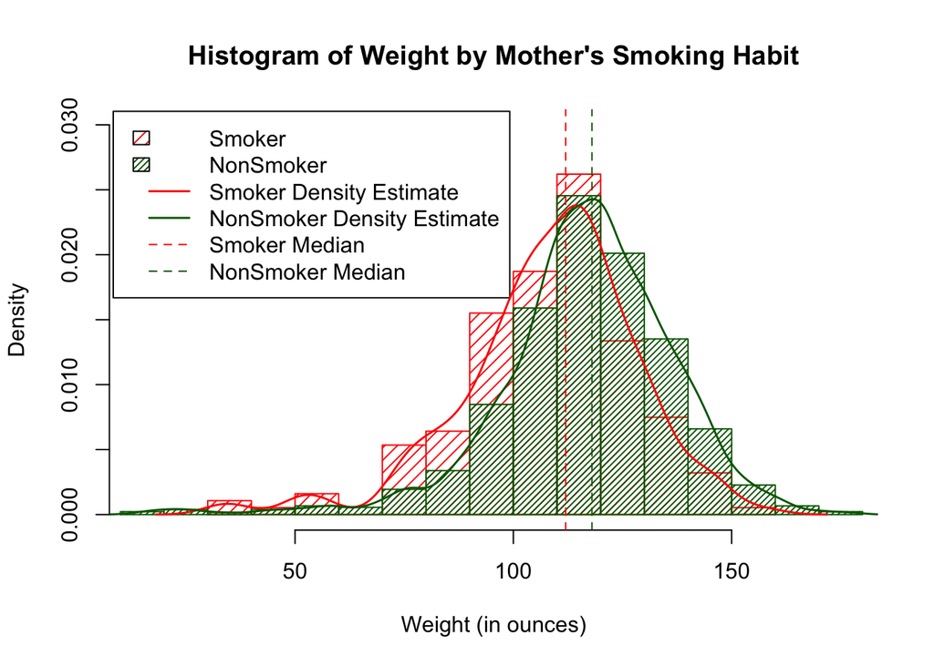

```r
with(births, hist(weight[Habit == "Smoker"],
            freq = FALSE,density = 15, col = "red",
            xlab = "Weight (in ounces)", main = "Histogram of Weight by Mother's Smoking Habit",
            xlim = range(weight), ylim = c(0,0.03)
                  ))


with(births, hist(weight[Habit == "NonSmoker"],
            freq = FALSE, density = 30, col = "darkgreen",
            breaks = 20, add = TRUE
                  ))

legend("topleft", c("Smoker", "NonSmoker", "Smoker Density Estimate", "NonSmoker Density Estimate", "Smoker Median", "NonSmoker Median"),
       density = c(15, 30, NA,NA,NA,NA),
       fill = c("red", "darkgreen",0,0,0,0), border= c(1,1,NA,NA,NA,NA),
       inset = 0.005, col = c(NA,NA, "red", "darkgreen", "red", "darkgreen"), lty = c(NA,NA, 1,1,2,2), lwd = c(NA,NA,1.5,1.5,1,1))

lines(density(births$weight[births$Habit == "Smoker"]), lwd = 1.5, col = "red")
lines(density(births$weight[births$Habit == "NonSmoker"]), lwd = 1.5, col = "darkgreen")

abline(v = summary(births$weight[births$Habit == "Smoker"])[3], lty = 2, col = "red")
abline(v = summary(births$weight[births$Habit == "NonSmoker"])[3], lty = 2, col = "darkgreen")
```

## Question 3

### Part a

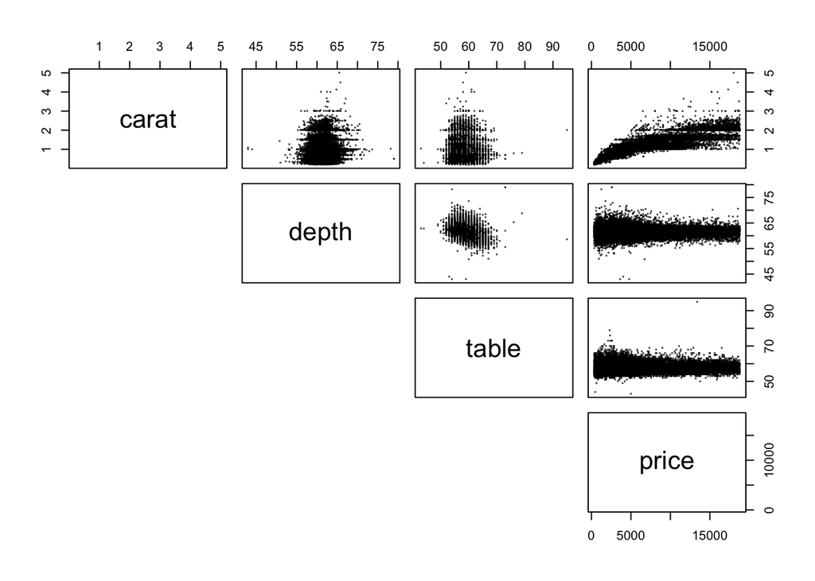

```r
library(ggplot2)
pairs(diamonds[, c("carat", "depth", "table", "price")], lower.panel = NULL, cex = 0.1)
```

carat and price seem to have the strongest relationship

### Part b

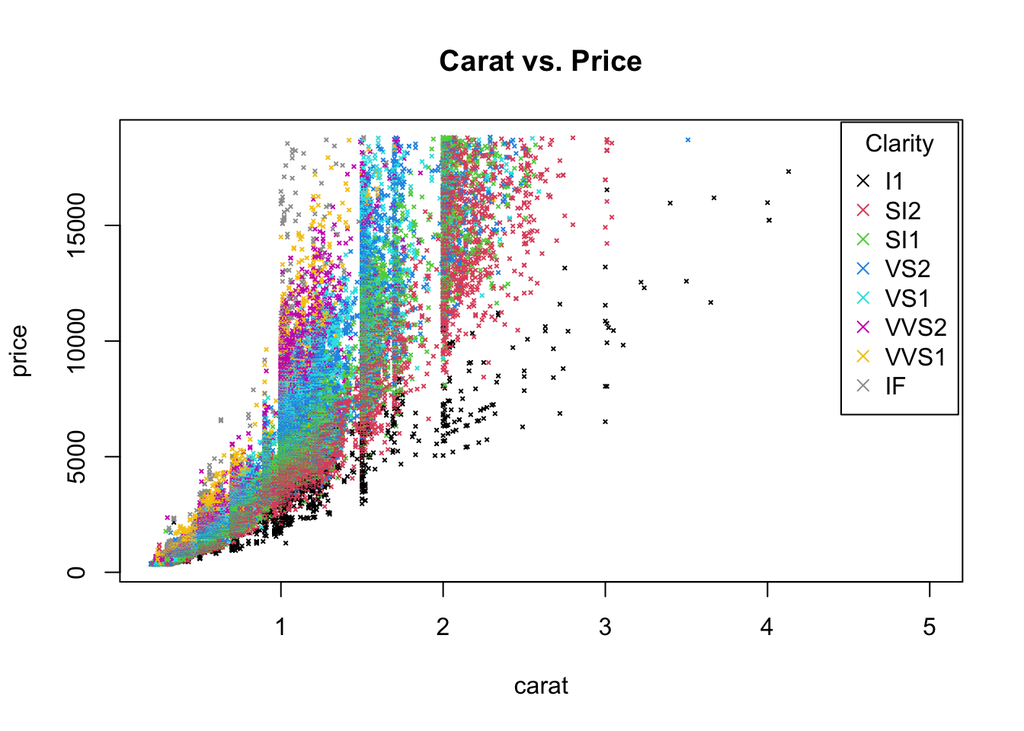

```r
plot(price ~ carat, data = diamonds, cex = 0.3, pch = 4, col = clarity, main = "Carat vs. Price")
legend("topright",
       legend = levels(diamonds$clarity),
       col = 1:length(diamonds$clarity),
       pch = 4,
       title = "Clarity",  inset = 0.005)
```

```r
## class(diamonds$clarity)
## clarity is an ordered factor.
```

The colors are assigned based on my R’s internal color palette, which can be customized. Each color is assigned a number and since there are 8 levels in clarity, each level will be of the color of that number. Ordered factors have a natural ordering, and the default color assignment reflects this order.

### Part c

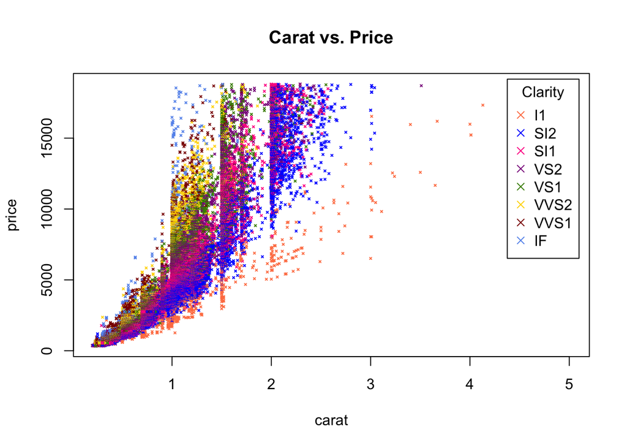

```r
custom_colors <- c("coral", "blue", "deeppink", "darkmagenta", "chartreuse4", "gold", "darkred", "cornflowerblue")

# Map clarity levels to custom colors
clarity_colors <- custom_colors[as.numeric(diamonds$clarity)]

plot(price ~ carat, data = diamonds, cex = 0.3, pch = 4, col = clarity_colors, main = "Carat vs. Price")

legend("topright",
       legend = levels(diamonds$clarity),
       col = custom_colors,
       pch = 4,
       title = "Clarity", inset = 0.02)
```

```r
## class(diamonds$clarity)
## clarity is an ordered factor.
```

### Part d

The higher the price, the diamonds more likely to be of “internally flawless”. Lower clarity grades, such as Included 1 (I1), are generally associated with lower-priced diamonds. Diamonds with more visible inclusions are considered less valuable. Diamonds with higher clarity grades tend to be more expensive. Heavier diamonds are more rare. We can also observe a trend where diamonds have larger carat weights but possibly lower prices due to the lower clarity grade. I’ve learned how “Internally Flawless” (IF) are considered very high-quality diamonds with no visible inclusions under 10x magnification. These diamonds are rarer and, therefore, tend to command higher prices.

## Question 4

### Part a

```r
mean_cut_color <- matrix(
  tapply(diamonds$price, list(diamonds$color, diamonds$cut), mean),
  nrow = length(levels(diamonds$color))
)
```

### Part b

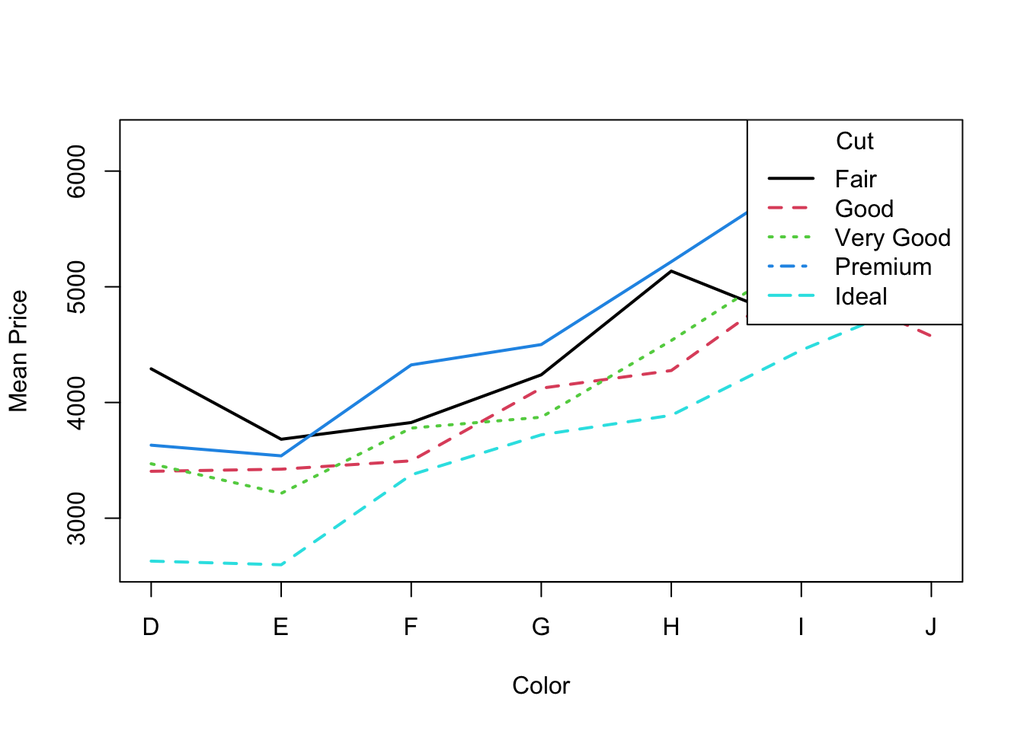

```r
# Create a matrix of mean prices for each color-cut combination
mean_cut_color <- matrix(
  tapply(diamonds$price, list(diamonds$color, diamonds$cut), mean),
  nrow = length(levels(diamonds$color))
)

rownames(mean_cut_color) <- levels(diamonds$color)
colnames(mean_cut_color) <- levels(diamonds$cut)

matplot(1:length(levels(diamonds$color)), mean_cut_color, type = "l", lty = 1:3, col = 1:6, lwd = 2, xaxt = "n", xlab = "Color", ylab = "Mean Price")

axis(1, at = 1:length(levels(diamonds$color)), labels = levels(diamonds$color))

legend("topright", legend = levels(diamonds$cut), col = 1:6, lty = 1:6, lwd = 2, title = "Cut")
```

### Part c

In ordered rank, color levels closer to J are of higher price. For cut, based on the ordered rank, it varies. Premium costs the highest, ideal costs the least. In increasing order: ideal, good, very good, fair, premium.

```r
mean_cut_color
```

```
##       Fair     Good Very Good  Premium    Ideal
## D 4291.061 3405.382  3470.467 3631.293 2629.095
## E 3682.312 3423.644  3214.652 3538.914 2597.550
## F 3827.003 3495.750  3778.820 4324.890 3374.939
## G 4239.255 4123.482  3872.754 4500.742 3720.706
## H 5135.683 4276.255  4535.390 5216.707 3889.335
## I 4685.446 5078.533  5255.880 5946.181 4451.970
## J 4975.655 4574.173  5103.513 6294.592 4918.186
```

```r
summary(mean_cut_color)
```

```
##       Fair           Good        Very Good       Premium         Ideal
##  Min.   :3682   Min.   :3405   Min.   :3215   Min.   :3539   Min.   :2598
##  1st Qu.:4033   1st Qu.:3460   1st Qu.:3625   1st Qu.:3978   1st Qu.:3002
##  Median :4291   Median :4123   Median :3873   Median :4501   Median :3721
##  Mean   :4405   Mean   :4054   Mean   :4176   Mean   :4779   Mean   :3655
##  3rd Qu.:4831   3rd Qu.:4425   3rd Qu.:4819   3rd Qu.:5581   3rd Qu.:4171
##  Max.   :5136   Max.   :5079   Max.   :5256   Max.   :6295   Max.   :4918
```

Premium has the highest mean price, while Ideal has the lowest mean price.